# Presidential Election 2016_fund contribution in New York State

**2016 presidential election is most Controversial Elections in US History. Both candidates have been accused or critisized a lot. Despite all that, both parties could raise large fund and news always shown Clinton campaign fund was more than Trump. But Trump won the election. So I would like to analyse my state (NY) to see really how they raised huge amounts and if the contribution correlates to results**

The data (CSV) for fund contributions in NY is downloaded at http://www.fec.gov/disclosurep/PDownload.do The CSV file format is available at ftp://ftp.fec.gov/FEC/Presidential_Map/2016/DATA_DICTIONARIES/CONTRIBUTOR_FORMAT.txt ***

**Lets check numbers on toal fund**

```
## [1] "Total contribution fund in NY state in Millions:"
## [2] "171"
```

```
##
## "Quantitative Statistics on all contributions"
##                                           Min.
##                                       "-10100"
##                                        1st Qu.
##                                           "15"
##                                         Median
##                                           "27"
##                                           Mean
##                                        "265.9"
##                                        3rd Qu.
##                                          "100"
##                                           Max.
##                                     "12780000"
```

We have some refunds (-ve numbers) in fund. The mean is outside 3rd quartile, we have lot of outlier contributions, The maximum contribution is 12mm, thats very huge comparing to median or 3rd quartile. Lets look at total fund for each candidate.

**Lets check total fund for each Candidate and statistics**

```
##                 Bush, Jeb       Carson, Benjamin S.
##                3587710.31                 634949.58
##  Christie, Christopher J.   Clinton, Hillary Rodham
##                 861362.00              145295984.12
## Cruz, Rafael Edward 'Ted'            Fiorina, Carly
##                1645886.58                 351623.23
##      Gilmore, James S III        Graham, Lindsey O.
##                   6400.00                 352772.07
##            Huckabee, Mike             Jindal, Bobby
##                 146771.50                  32176.42
##             Johnson, Gary           Kasich, John R.
##                 246860.47                 865267.25
##          Lessig, Lawrence            McMullin, Evan
##                  64772.31                  30187.50
##   O'Malley, Martin Joseph         Pataki, George E.
##                 252807.00                 317354.29
##                Paul, Rand    Perry, James R. (Rick)
##                 262448.15                  16700.00
##              Rubio, Marco          Sanders, Bernard
##                2386984.25                8052175.21
##      Santorum, Richard J.               Stein, Jill
##                  27055.10                  89991.10
##          Trump, Donald J.             Walker, Scott
##                5358427.32                 228423.00
##     Webb, James Henry Jr.
##                  34700.00
```

*It seems we have lot of variations in contributions between candidates, lets look at visualizations to better understand contribtuions*

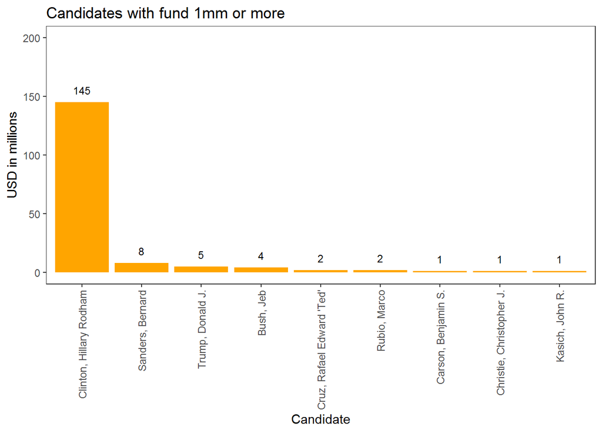

It appears that, the donations for Clinton were too high compare to any other candidate. She has 145mm (appx) and the second comes Sanders with 8mm.

Lets analyze donations for Clinton and Sanders by election type as both of these were key candidates from democrats in primary elections.

*Number of Contributor by election type*

```
##
##         G2016  P2015  P2016  P2020
##    869 265553      1 377122      3
```

We have 869 entries with no value for election type, lets see how much fund comes out of these entries

## Contributions with Election Type Blank

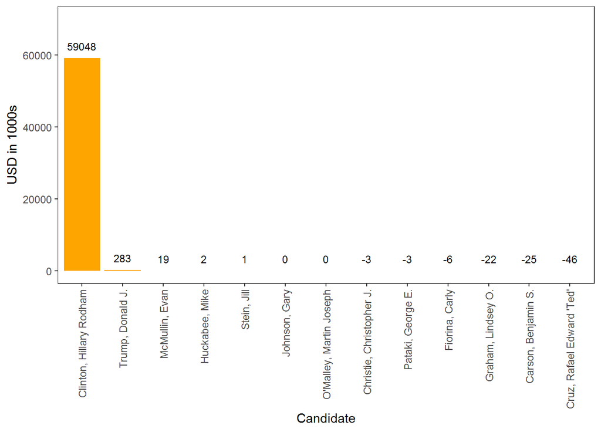

It appears that, Clinton has got 59mn out of these entries, this is 40% of her total fund, so we can???t ignore this to analyze data by election type. We could consider wrangling and deriving this based on donation date and primary election date etc, (donations might also be generic so candidate can use how ever they need) but let’s not worry about data mining and just look at contribution types for this unclassified amount.

Lets compare this fund by form type to see whether individuals or PACs are part of this amount.

### Contribution source of Blank election type

- SA17A (individual contributions), SB28A (refunds to individuals), and SA18 (transfers from other authorized committees) *

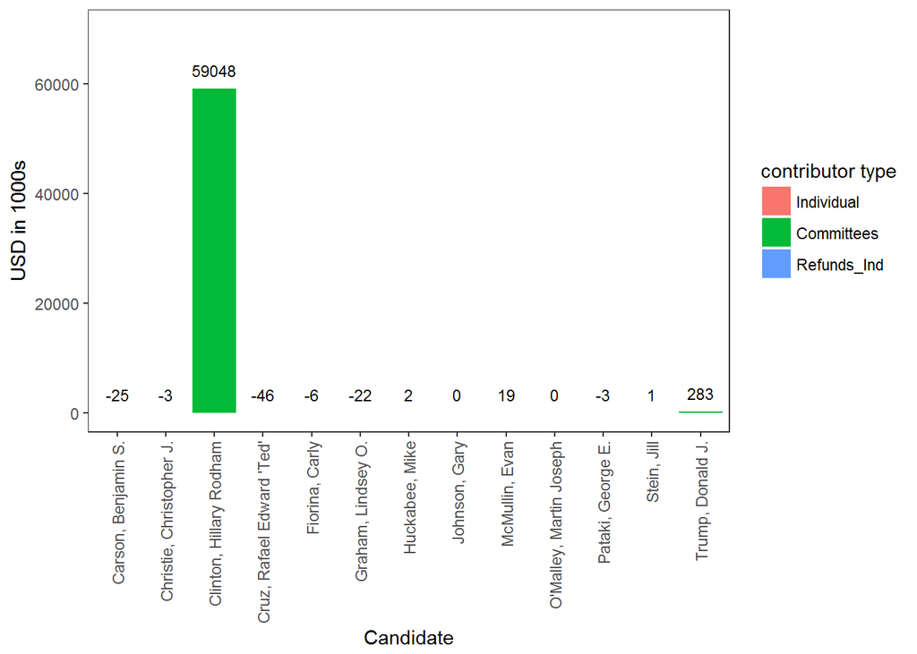

It is interesting that all unclassified amount contributed from Committees, so let’s not worry about these, we will focus analysis on Individual contributions.

**Compare data between Clinton and Sanders by election type (primary or general)**

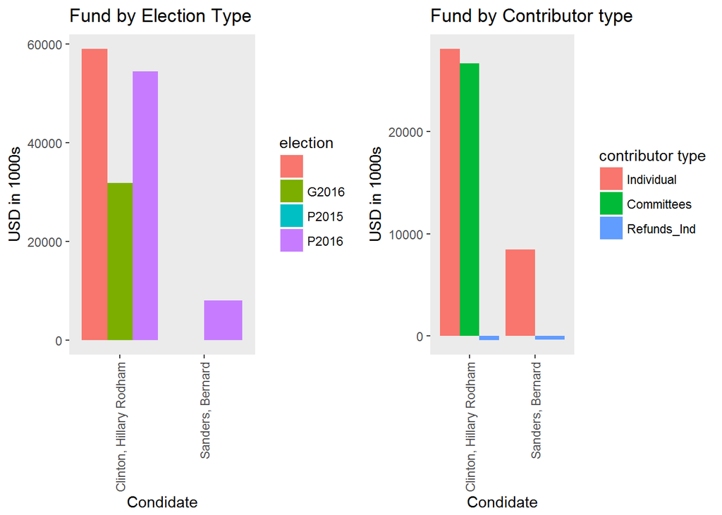

It appears entire Bernie sanders fund contributed for primary it makes sense as he lost in primary.

If we check primary election result of NY, there is no huge difference for both candidates. (It is interesting that Sanders did not have any Committee fund, the 100% of his fund contributed by individuals and he pulled primary well) This is primary election result from NY Times. http://www.nytimes.com/elections/2016/results/primaries/new-york

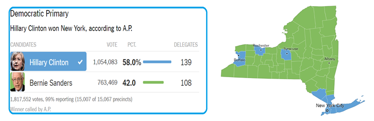

But if we look at primary election fund (P2016), there is huge difference. It is not necessariliy all NY primary fund is contributed before NY primary elections. So lets see the spread for the dates and also we will explore contibutors area to see if it matches with above map.

## Explore Individual donations for Primary election

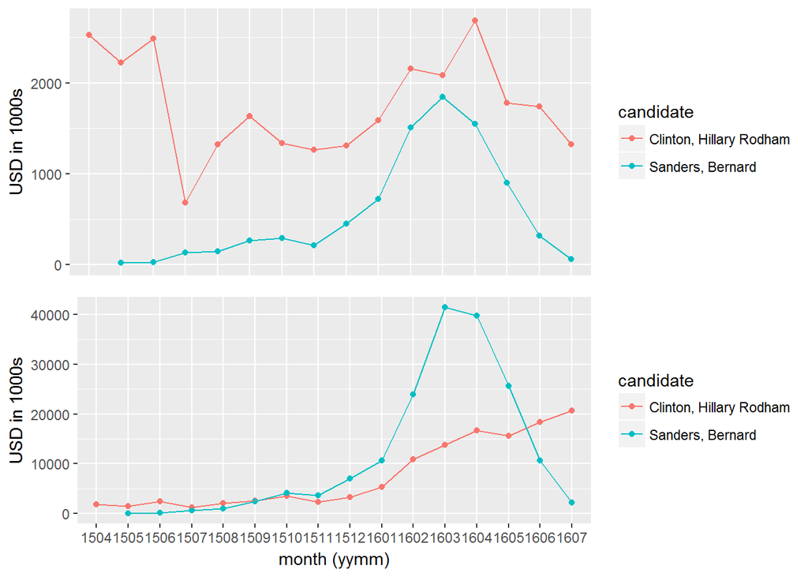

But the number of contributors are high for Sanders, that tells me that most of the Sanders donors are middle clasee or lower middle class and most of them might have donated smaller amounts.

Most of the higher class people live in metro areas with white collor jobs.

*Lets check top 10 occupations for both candidates in primary election fund and compare with entire state fund*

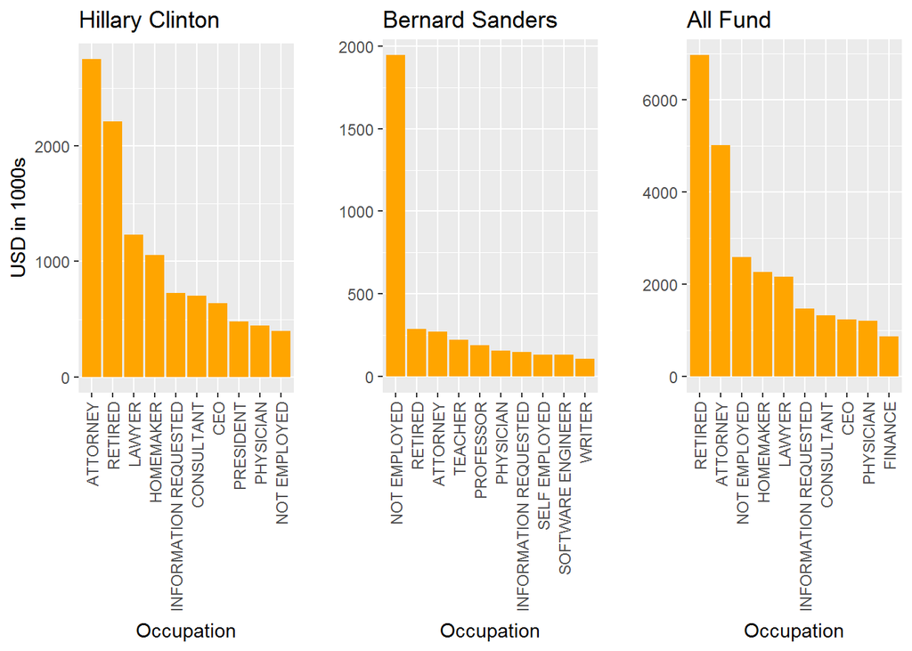

*The another interesting point is, why retired people are at the top of donations? Their life is completely dependent on policies like social security and medicaid, this might be one of the reason they are very interested on election outcome!*

*Lets check top 10 occupations for Clinton and Trump*

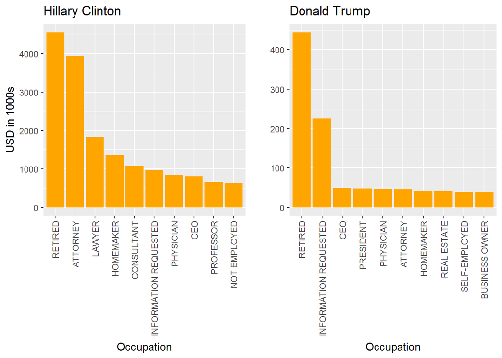

Again retired is on top for both of the candidates. **Real Estate owners are on top 10 for Donald Trump, but clinton does not have them on top, Trump made fortune in real estate, so they must have thought he creates real estate pro policies** *But this can not be confirmed as Clinton fund in number is too high. We will later look at more occupations for clinton!*

**lets check Clinton data has REAL ESTATE occupation in next top contributors falling above 100k**

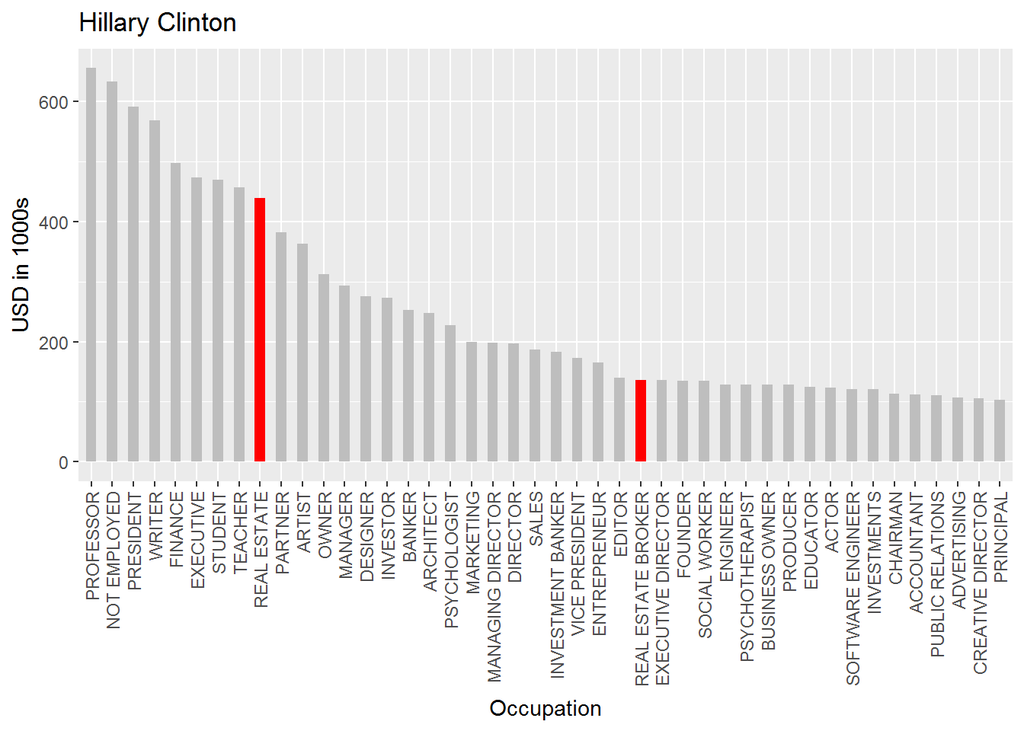

Look at this, Clinton does not have REAL ESTATE on top 10 occupations but has around 450k from Real estate, thats way higher than Trump contributions from REAL ESTATE (45k). Also plot shows another relevant occupation ‘REAL ESTATE BROKER’ with around 125K for Clinton. So if we believed real estate workers wanted Trump to win, it turned incorrect.

**Lets see area wise plot for both parties**

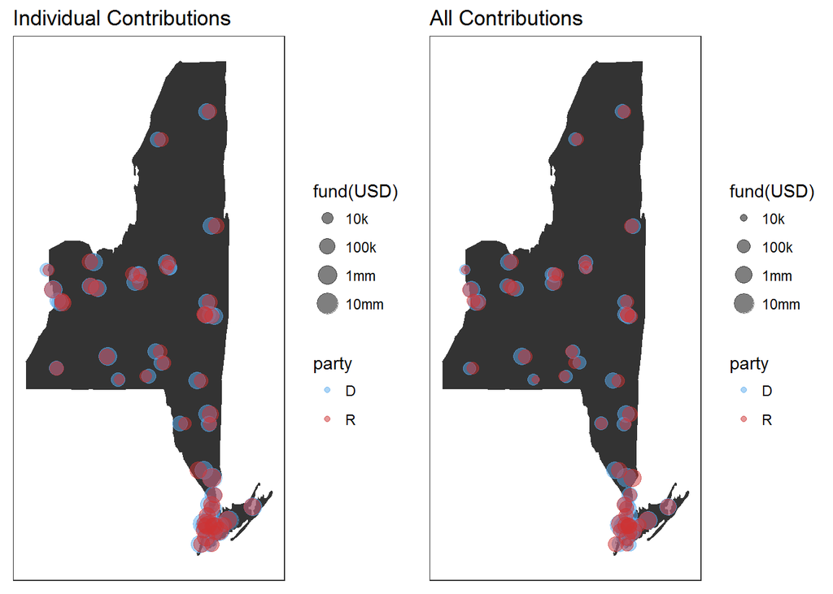

**No difference between these 2 indcates, individual and commettes contributed from same area.** It shows larger points for Democratic party in all given areas. Here is the presidential result from NY Times. **There is one interesting, if you compare dark red areas in result (republicans got more than 60% vote) to above map, all those areas do not have donations for any party! This might indicate, lower middle class (who can not donate) voted for Trump.** *We will confirm this more accurately when we plot fund by presidential Candidates for area* http://www.nytimes.com/elections/results/new-york

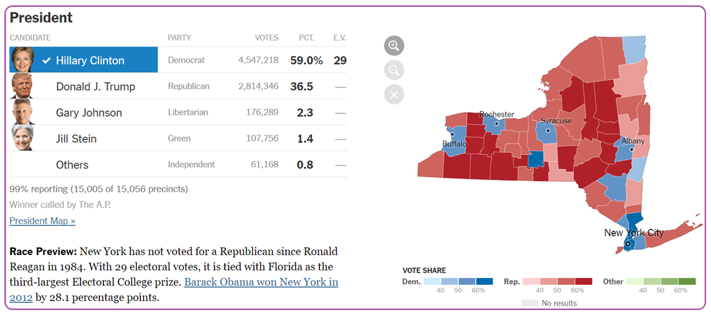

**Lets compare area wise donation and result for Democratic Primary election**

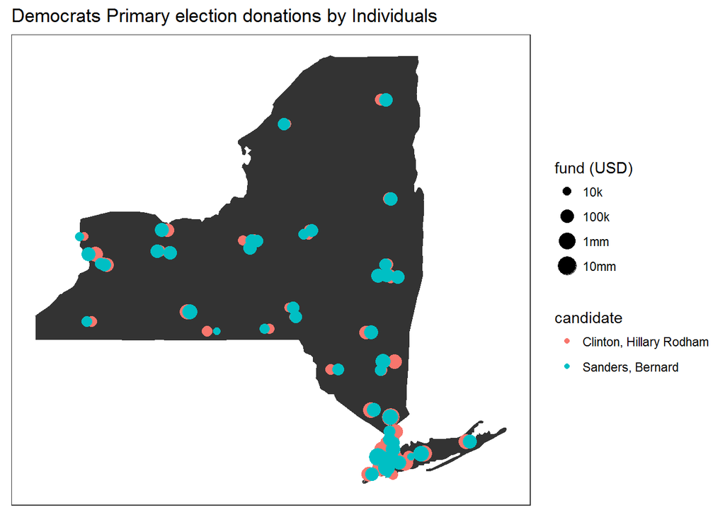

**Lets compare area wise donation and result for presidential election candidates** **Clinton Vs Trump**

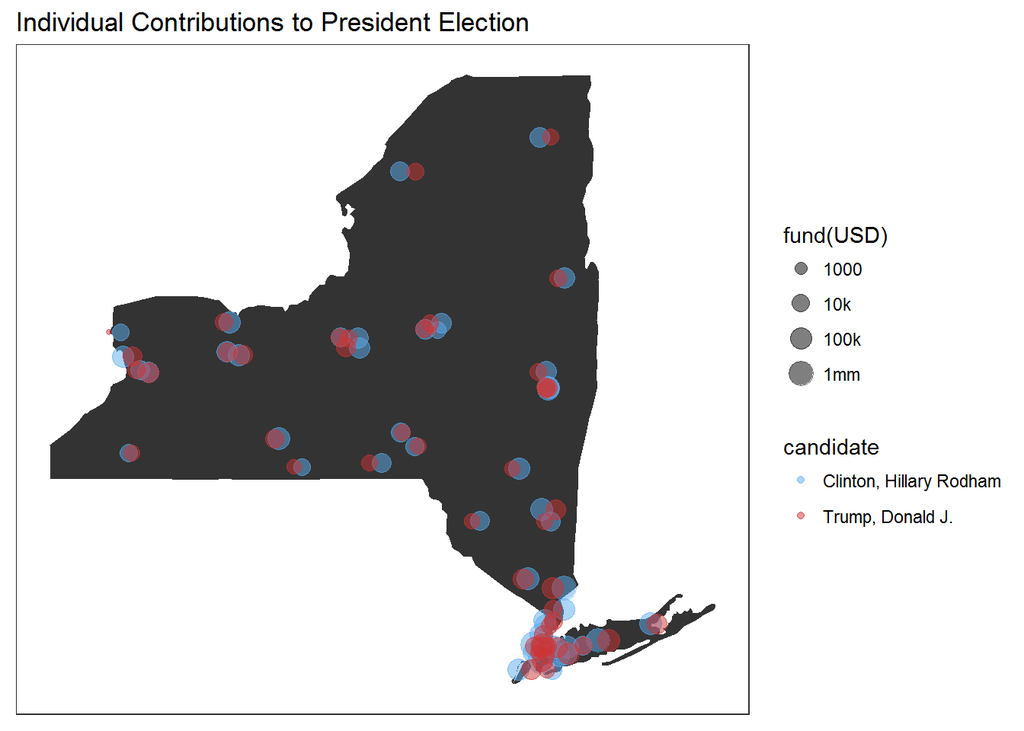

*This confirms what we assumed when we compared data between parties, all areas with donations have given high vote to Clinton or slight margin for trump. No donation areas are clearly won by Trump (60% vote).*

# Reflection

I was also interested to explore donations and election results based on contributor occupation in more detailed, but occupations are very narrowed in data, so that becomes difficult, if we have occupations at high level, it would help us to create occupation categorical plots. Ofcourse we could map occupations in data to high level categories using any mapping data, but that involves some data wrangling.

If I had geneder variable, it would have helped to explore if there was any gender bias in donations.

Based on NY state data analysis and conclusions, I am very curious to run this analysis in future for all states and explore if there is any correlation between donation and election result by small region.